# 河南省《五大洲发病率第12卷》数据上报审核程序

登记处：济源市

2013-2017年

Qiong Chen @ Henan Cancer Center/Henan Cancer Hospital

2022-06-21

[figure not shown]

# 1 基本情况介绍

济源市肿瘤登记处拟上报2013至2017年肿瘤登记数据至五大洲发病率第12卷。

河南省肿瘤登记处按照《五大洲发病率》收录数据审核标准对河南省各登记处拟上报年份范围的数据质量进行了图形化展示，各登记处可根据审核结果完善核实本登记处数据！

> 本结果分如下几个部分：
> 1. 基本情况介绍
> 2. 人口数据审核
> 3. 总体癌症发病死亡情况
> 4. 主要部位癌症发病死亡情况
> 5. 年龄别率
> 6. 儿童肿瘤发病率/死亡率
> 7. 主要质量控制指标情况(登记癌种数、MV%、M:I、DCO%)

# 2 人口数据审核

> 人口数据质量对于肿瘤登记数据质量至关重要，本程序对于人口数据的审核从**人口总数**、**人口性别比例**、以>及**人口金字塔**等三个方面进行。

## 2.1 人口总数变化情况

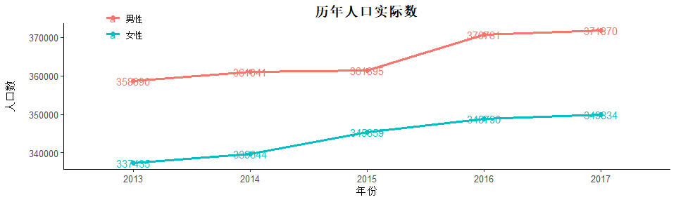

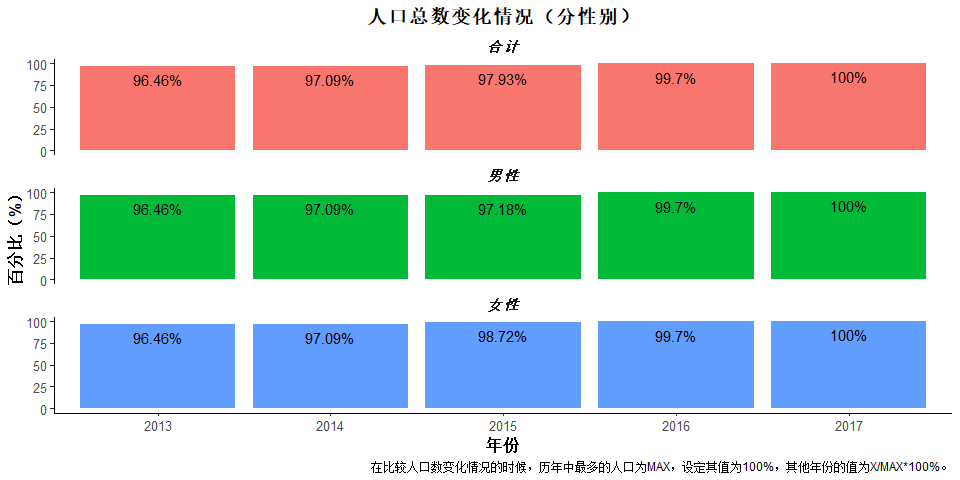

## 2.2 性别比例变化情况

> 性别比例反映一个地区男女性别构成的情况，全国第七次人口普查数据结果显示，男女性别比为105.07（以女性为100计算）。

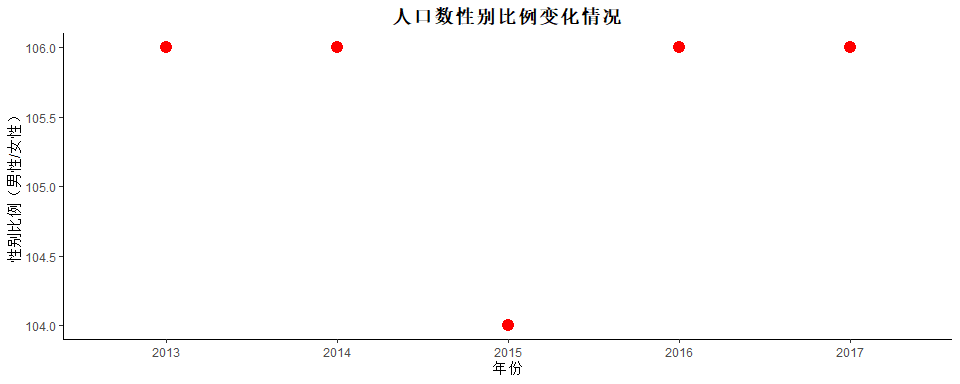

## 2.3 人口金字塔变化情况

> 人口金字塔是用类似古埃及金字塔的形象描绘人口年龄和性别分布状况的图形。能表明人口现状及其发展类型。

> 图形的画法是：按男女人口年龄自然顺序自下而上在纵轴左右画成并列的横条柱，各条柱代表各个年龄组。底端标有按一定计算单位或百分比表示的人口数量，可见R程序[^1]。

> 人口金字塔可概括为三种类型：
> 1. *扩张型* ，年轻人口组比重较大，从最低年龄组到最高年龄组依次逐渐缩小，塔形下宽上尖。
> 2. *稳定型* ，除最老年龄组外，其余各年龄组大致相差不多，扩大或缩小均不明显，塔形较直。
> 3. *收缩型* ，年轻人口组有规则的逐渐缩小，中年以上各组比重较大，塔形下窄上宽。

### 2.3.1 历年人口结构动态变化

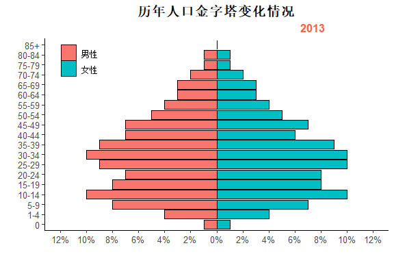

### 2.3.2 历年人口结构逐年展示

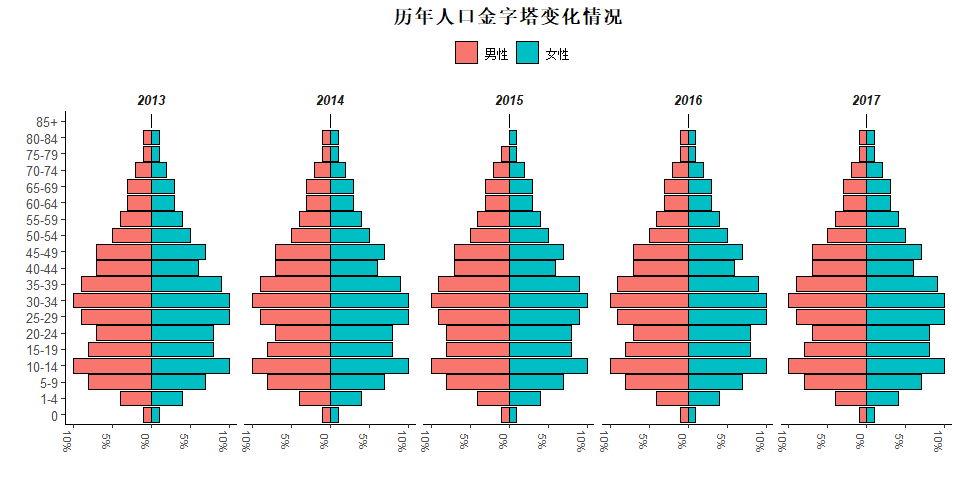

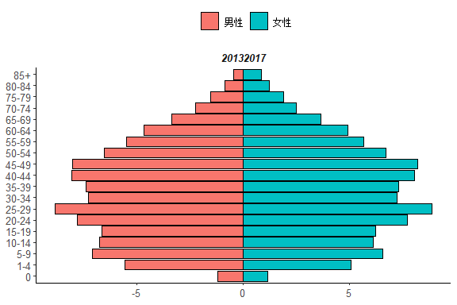

# 3 总体癌症发病死亡情况

## 3.1 总体癌症发病数、死亡数

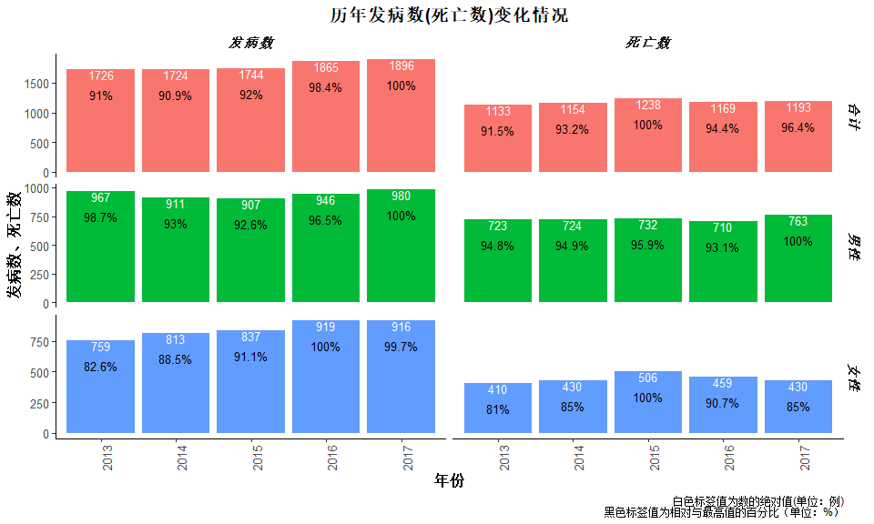

## 3.2 总体癌症发病率

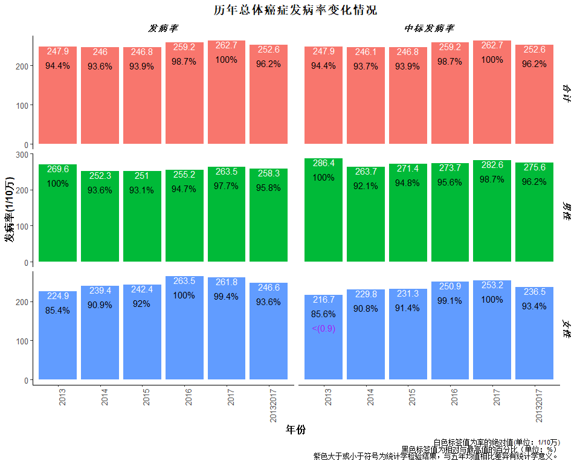

## 3.3 总体癌症死亡率

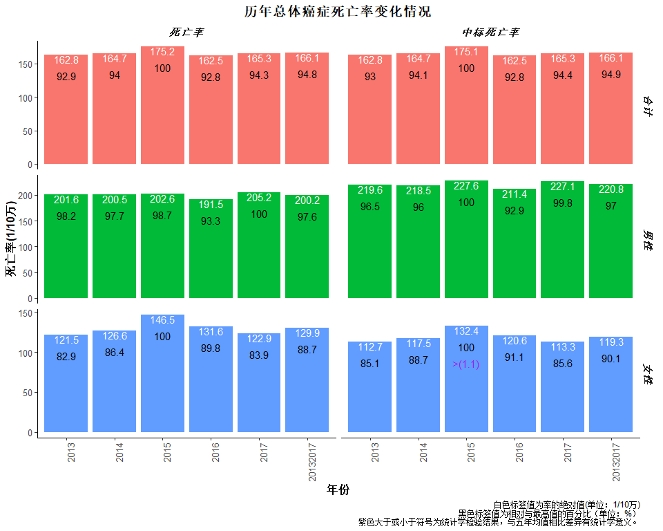

# 4 主要部位恶性肿瘤*发病/死亡*情况

## 4.1 发病情况

### 4.1.1 发病数（构成比）情况

各年份肿瘤发病数(构成比%)情况

| code | 2013 | 2014 | 2015 | 2016 | 2017 | 20132017 |
| --- | --- | --- | --- | --- | --- | --- |
| **男性** |  |  |  |  |  |  |
| 所有部位 | 967 ( 100 ) | 911 ( 100 ) | 907 ( 100 ) | 946 ( 100 ) | 980 ( 100 ) | 4711 ( 100 ) |
| 肺 | 141 ( 14.6 ) | 134 ( 14.7 ) | 130 ( 14.3 ) | 142 ( 15 ) | 158 ( 16.1 ) | 705 ( 15 ) |
| 胃 | 332 ( 34.3 ) | 307 ( 33.7 ) | 318 ( 35.1 ) | 318 ( 33.6 ) | 345 ( 35.2 ) | 1620 ( 34.4 ) |
| 肝 | 108 ( 11.2 ) | 96 ( 10.5 ) | 91 ( 10 ) | 98 ( 10.4 ) | 105 ( 10.7 ) | 498 ( 10.6 ) |
| 食管 | 129 ( 13.3 ) | 98 ( 10.8 ) | 120 ( 13.2 ) | 121 ( 12.8 ) | 104 ( 10.6 ) | 572 ( 12.1 ) |
| 结直肠 | 60 ( 6.2 ) | 50 ( 5.5 ) | 45 ( 5 ) | 70 ( 7.4 ) | 61 ( 6.2 ) | 286 ( 6.1 ) |
| 乳房 | 0 ( 0 ) | 0 ( 0 ) | 1 ( 0.1 ) | 1 ( 0.1 ) | 1 ( 0.1 ) | 3 ( 0.1 ) |
| 宫颈 | 0 ( 0 ) | 0 ( 0 ) | 0 ( 0 ) | 0 ( 0 ) | 0 ( 0 ) | 0 ( 0 ) |
| 脑 | 25 ( 2.6 ) | 17 ( 1.9 ) | 25 ( 2.8 ) | 25 ( 2.6 ) | 16 ( 1.6 ) | 108 ( 2.3 ) |
| 甲状腺 | 4 ( 0.4 ) | 8 ( 0.9 ) | 15 ( 1.6 ) | 11 ( 1.2 ) | 24 ( 2.5 ) | 62 ( 1.3 ) |
| 淋巴瘤 | 4 ( 0.4 ) | 11 ( 1.2 ) | 15 ( 1.6 ) | 11 ( 1.2 ) | 12 ( 1.2 ) | 53 ( 1.1 ) |
| 白血病 | 23 ( 2.4 ) | 20 ( 2.2 ) | 22 ( 2.4 ) | 18 ( 1.9 ) | 9 ( 0.9 ) | 92 ( 2 ) |
| **女性** |  |  |  |  |  |  |
| 所有部位 | 759 ( 100 ) | 813 ( 100 ) | 837 ( 100 ) | 919 ( 100 ) | 916 ( 100 ) | 4244 ( 100 ) |
| 肺 | 59 ( 7.8 ) | 81 ( 10 ) | 84 ( 10 ) | 92 ( 10 ) | 80 ( 8.7 ) | 396 ( 9.3 ) |
| 胃 | 138 ( 18.2 ) | 110 ( 13.5 ) | 118 ( 14.1 ) | 139 ( 15.1 ) | 130 ( 14.2 ) | 635 ( 15 ) |
| 肝 | 68 ( 9 ) | 36 ( 4.4 ) | 46 ( 5.5 ) | 64 ( 7 ) | 49 ( 5.3 ) | 263 ( 6.2 ) |
| 食管 | 80 ( 10.5 ) | 96 ( 11.8 ) | 78 ( 9.3 ) | 65 ( 7.1 ) | 61 ( 6.7 ) | 380 ( 8.9 ) |
| 结直肠 | 37 ( 4.9 ) | 54 ( 6.6 ) | 50 ( 6 ) | 58 ( 6.3 ) | 70 ( 7.6 ) | 269 ( 6.3 ) |
| 乳房 | 70 ( 9.2 ) | 92 ( 11.3 ) | 101 ( 12.1 ) | 105 ( 11.4 ) | 125 ( 13.7 ) | 493 ( 11.6 ) |
| 宫颈 | 101 ( 13.3 ) | 75 ( 9.2 ) | 120 ( 14.3 ) | 127 ( 13.8 ) | 137 ( 15 ) | 560 ( 13.2 ) |
| 脑 | 20 ( 2.6 ) | 20 ( 2.5 ) | 16 ( 1.9 ) | 26 ( 2.8 ) | 24 ( 2.6 ) | 106 ( 2.5 ) |
| 甲状腺 | 29 ( 3.8 ) | 25 ( 3.1 ) | 33 ( 3.9 ) | 51 ( 5.6 ) | 82 ( 8.9 ) | 220 ( 5.2 ) |
| 淋巴瘤 | 6 ( 0.8 ) | 7 ( 0.9 ) | 17 ( 2 ) | 9 ( 1 ) | 7 ( 0.8 ) | 46 ( 1.1 ) |
| 白血病 | 13 ( 1.7 ) | 18 ( 2.2 ) | 18 ( 2.1 ) | 13 ( 1.4 ) | 6 ( 0.7 ) | 68 ( 1.6 ) |

### 4.1.2 标化发病率变化（图示）

#### 4.1.2.1 稳定性评价

> 稳定性评价主要通过各年份标化发病率与期间（2013-2017）平均值对比，来展示各登记处率的稳定性，并进行统计学检验。 1. *直观展示*：主要部位恶性肿瘤标化发病率的数值大小通过对应色块的颜色深浅来表示，较深的颜色代表较高的值，如果不 同年份之间色块出现跳跃则表示率变化波动较大。 1. *统计学检验*：按照五大洲发病率，标化率差异的统计学检验方法，比较各年份值与期间平均值相比有无统计学差异。

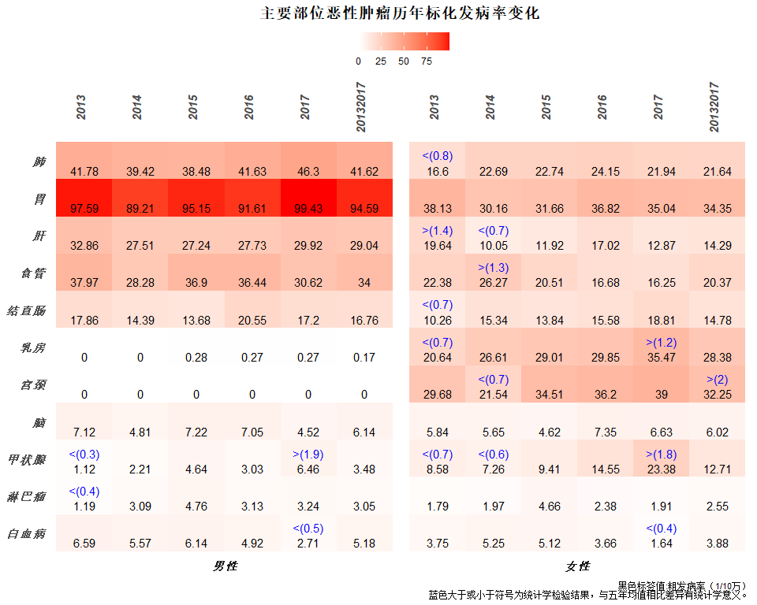

#### 4.1.2.2 与区域标准比较

本部分主要通过把标化发病率与河南省所有上报五大洲数据的平均指标相比来表示差异大小,指标为(O/E)。

> $$(O/E)=\frac{登记处标化发病率}{同时期内所有上报五大洲登记处平均期望值}$$

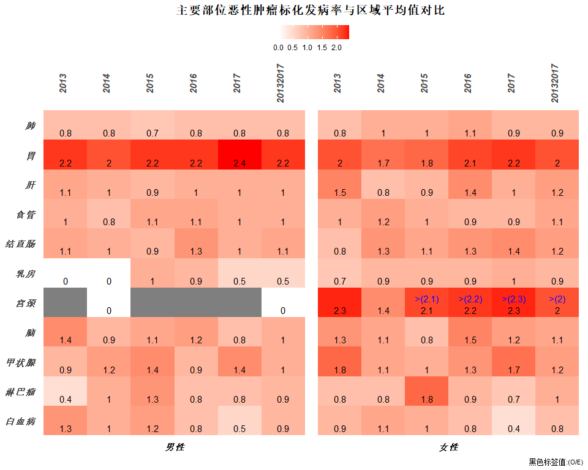

## 4.2 死亡情况

### 4.2.1 死亡数(构成比)情况

各年份肿瘤死亡数(构成比%)情况

| code | 2013 | 2014 | 2015 | 2016 | 2017 | 20132017 |
| --- | --- | --- | --- | --- | --- | --- |
| **男性** |  |  |  |  |  |  |
| 所有部位 | 723 ( 100 ) | 724 ( 100 ) | 732 ( 100 ) | 710 ( 100 ) | 763 ( 100 ) | 3652 ( 100 ) |
| 肺 | 112 ( 15.5 ) | 129 ( 17.8 ) | 119 ( 16.3 ) | 129 ( 18.2 ) | 142 ( 18.6 ) | 631 ( 17.3 ) |
| 胃 | 255 ( 35.3 ) | 250 ( 34.5 ) | 246 ( 33.6 ) | 247 ( 34.8 ) | 269 ( 35.3 ) | 1267 ( 34.7 ) |
| 肝 | 95 ( 13.1 ) | 88 ( 12.2 ) | 83 ( 11.3 ) | 96 ( 13.5 ) | 104 ( 13.6 ) | 466 ( 12.8 ) |
| 食管 | 118 ( 16.3 ) | 86 ( 11.9 ) | 96 ( 13.1 ) | 92 ( 13 ) | 90 ( 11.8 ) | 482 ( 13.2 ) |
| 结直肠 | 28 ( 3.9 ) | 28 ( 3.9 ) | 27 ( 3.7 ) | 31 ( 4.4 ) | 34 ( 4.5 ) | 148 ( 4 ) |
| 乳房 | 0 ( 0 ) | 2 ( 0.3 ) | 1 ( 0.1 ) | 0 ( 0 ) | 1 ( 0.1 ) | 4 ( 0.1 ) |
| 宫颈 | 0 ( 0 ) | 0 ( 0 ) | 0 ( 0 ) | 0 ( 0 ) | 0 ( 0 ) | 0 ( 0 ) |
| 脑 | 13 ( 1.8 ) | 16 ( 2.2 ) | 19 ( 2.6 ) | 18 ( 2.5 ) | 17 ( 2.2 ) | 83 ( 2.3 ) |
| 甲状腺 | 0 ( 0 ) | 0 ( 0 ) | 4 ( 0.6 ) | 1 ( 0.1 ) | 3 ( 0.4 ) | 8 ( 0.2 ) |
| 淋巴瘤 | 2 ( 0.3 ) | 4 ( 0.6 ) | 8 ( 1.1 ) | 8 ( 1.1 ) | 11 ( 1.4 ) | 33 ( 0.9 ) |
| 白血病 | 9 ( 1.2 ) | 20 ( 2.8 ) | 17 ( 2.3 ) | 13 ( 1.8 ) | 8 ( 1 ) | 67 ( 1.8 ) |
| **女性** |  |  |  |  |  |  |
| 所有部位 | 410 ( 100 ) | 430 ( 100 ) | 506 ( 100 ) | 459 ( 100 ) | 430 ( 100 ) | 2235 ( 100 ) |
| 肺 | 45 ( 11 ) | 55 ( 12.8 ) | 72 ( 14.2 ) | 79 ( 17.2 ) | 61 ( 14.2 ) | 312 ( 14 ) |
| 胃 | 90 ( 22 ) | 95 ( 22.1 ) | 99 ( 19.6 ) | 102 ( 22.2 ) | 100 ( 23.3 ) | 486 ( 21.7 ) |
| 肝 | 39 ( 9.5 ) | 31 ( 7.2 ) | 43 ( 8.5 ) | 51 ( 11.1 ) | 45 ( 10.5 ) | 209 ( 9.3 ) |
| 食管 | 62 ( 15.1 ) | 71 ( 16.5 ) | 71 ( 14 ) | 58 ( 12.6 ) | 39 ( 9.1 ) | 301 ( 13.5 ) |
| 结直肠 | 30 ( 7.3 ) | 16 ( 3.7 ) | 26 ( 5.1 ) | 28 ( 6.1 ) | 27 ( 6.3 ) | 127 ( 5.7 ) |
| 乳房 | 25 ( 6.1 ) | 16 ( 3.7 ) | 34 ( 6.7 ) | 23 ( 5 ) | 29 ( 6.7 ) | 127 ( 5.7 ) |
| 宫颈 | 25 ( 6.1 ) | 16 ( 3.7 ) | 32 ( 6.3 ) | 20 ( 4.4 ) | 16 ( 3.7 ) | 109 ( 4.9 ) |
| 脑 | 10 ( 2.4 ) | 16 ( 3.7 ) | 15 ( 3 ) | 10 ( 2.2 ) | 18 ( 4.2 ) | 69 ( 3.1 ) |
| 甲状腺 | 3 ( 0.7 ) | 3 ( 0.7 ) | 3 ( 0.6 ) | 1 ( 0.2 ) | 1 ( 0.2 ) | 11 ( 0.5 ) |
| 淋巴瘤 | 2 ( 0.5 ) | 7 ( 1.6 ) | 11 ( 2.2 ) | 5 ( 1.1 ) | 7 ( 1.6 ) | 32 ( 1.4 ) |
| 白血病 | 5 ( 1.2 ) | 11 ( 2.6 ) | 10 ( 2 ) | 13 ( 2.8 ) | 8 ( 1.9 ) | 47 ( 2.1 ) |

### 4.2.2 标化死亡率变化

#### 4.2.2.1 稳定性评价

> 稳定性评价主要通过各年份标化死亡率与期间（2013-2017）平均值对比，来展示各登记处率的稳定性，并进行统计学检验。
> 1. *直观展示*：主要部位恶性肿瘤标化死亡率的数值大小通过对应色块的颜色深浅来表示，较深的颜色代表较高的值，如果不 同年份之间色块出现跳跃则表示率变化波动较大。
> 1. *统计学检验*：按照五大洲发病率，标化率差异的统计学检验方法，比较各年份值与期间平均值相比有无统计学差异。

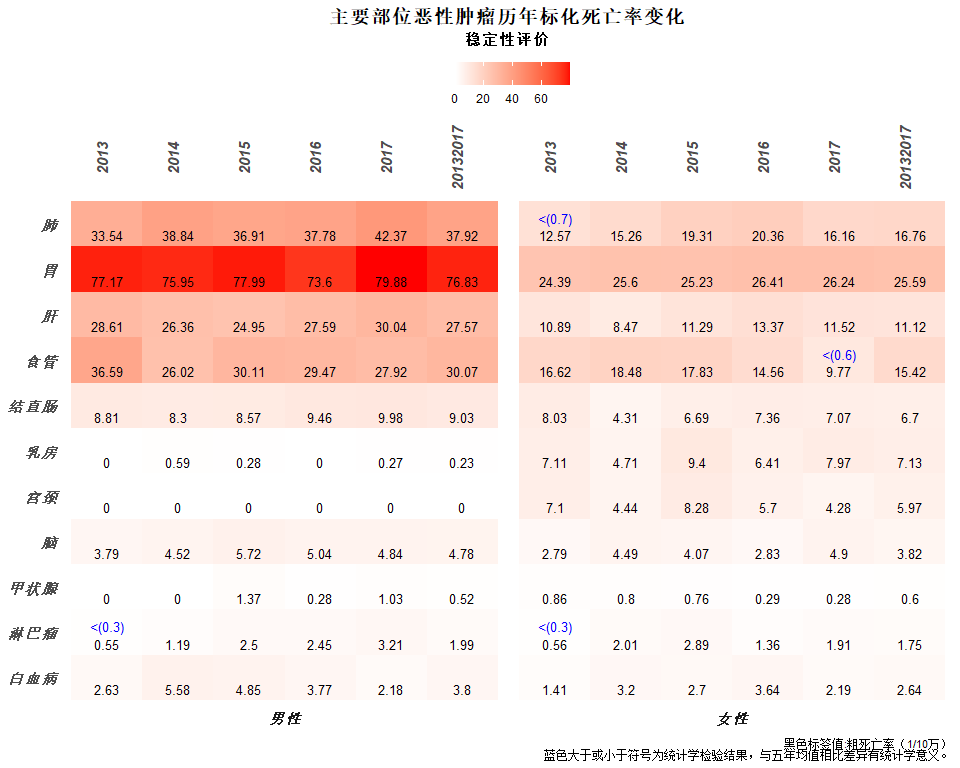

#### 4.2.2.2 与区域标准比较

本部分主要通过把标化死亡率与河南省所有上报五大洲数据的平均指标相比来表示差异大小,指标为(O/E)。

> $$(O/E)=\frac{登记处标化死亡率}{同时期内所有上报五大洲登记处平均期望值}$$

> 采用五大洲发病率第10卷统计学方法进行差异的统计学检验，“>”/“<”表示与期望值相比差异具有统计学意义。

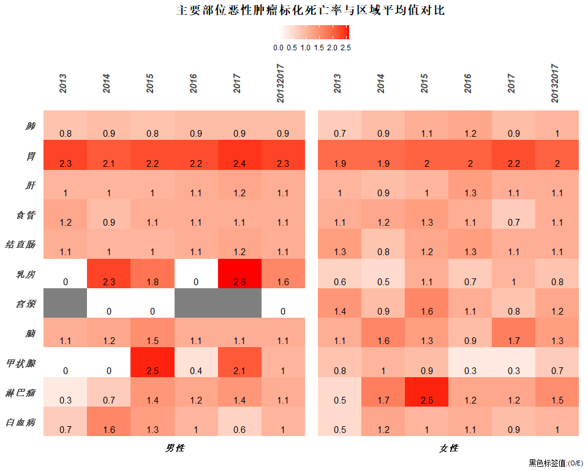

# 5 年龄别发病率/死亡率

> 1. 检查常见部位癌症分性别的*年龄别发病率/死亡率*曲线是质量评价流程的一个部分；
> 2. 发现年龄组发病率非正常波动（与预期望模式比较）， 如：率在上升年龄段（老年组）中的意外下降， 提示该年龄组发病存在漏报;
> 3. 同时也可检测年龄组人口分布存在的问题；

## 5.1 年龄别发病率

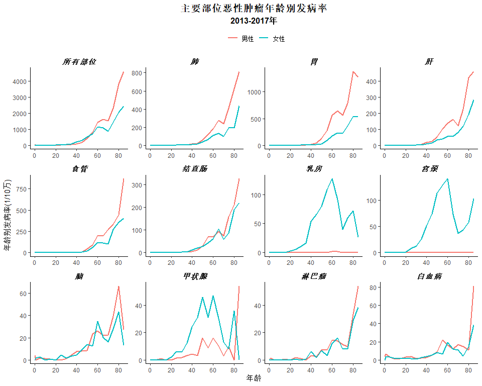

## 5.2 年龄别死亡率

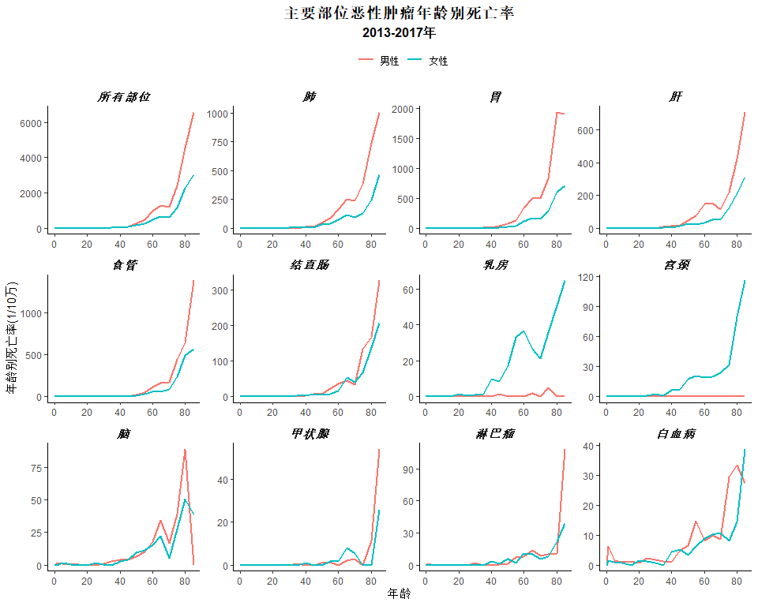

# 6 儿童癌症发病率（0-14岁）

> 1. 相对于成年人群，儿童癌症（所有部位合并）的发病率变异较小（儿童某些部位癌症发病率存在地区和种族差异）；
> 2. 分三个年龄组评价：0-4, 5-9，10-14；
> 3. 以前一时期的儿童癌症发病率为参照值，分性别、年龄组设定最低和最高值；
> 4. 发病率超出上下限定范围，认为存在漏报或重报的可能性。

## 6.1 发病率稳定性评价

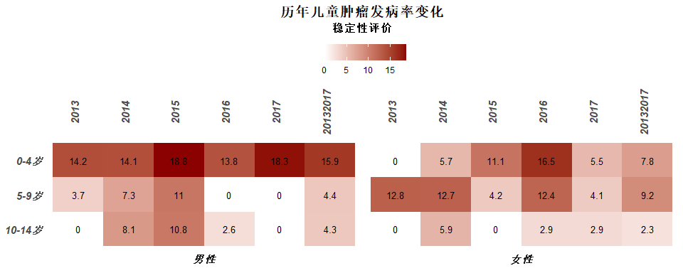

## 6.2 发病率与区域标准比较

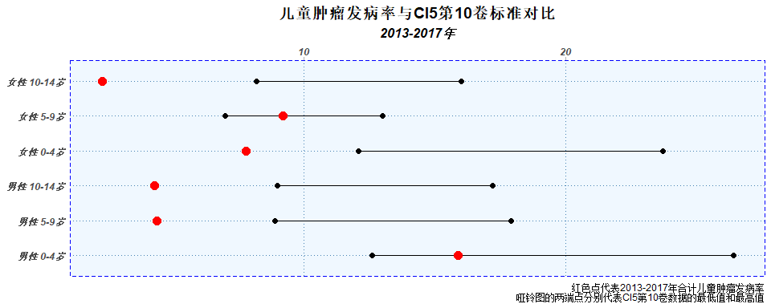

## 6.3 死亡率稳定性评价

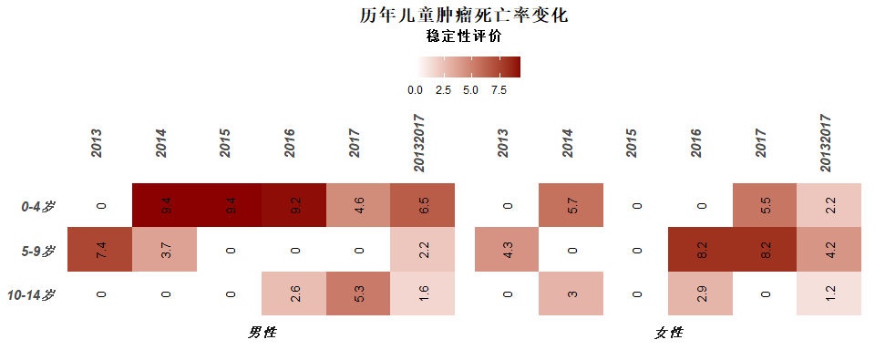

# 7 主要质量控制指标

## 7.1 历年癌种数变化情况

> 登记处每年收集的癌种数在一定程度上反映了数据收集的完整性

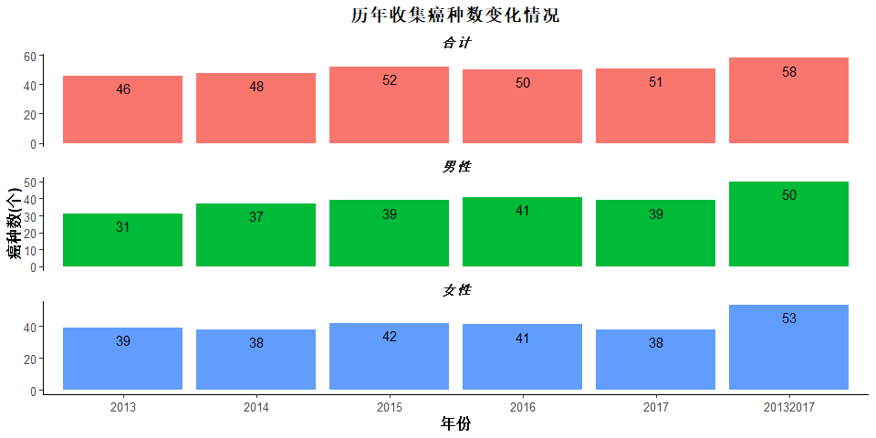

## 7.2 病理诊断比例(MV%)变化

> $$MV=\frac{时期内病理学确诊癌症病例数}{时期内所有癌症新发病例数}*100$$
> 1. 过高的MV%提示登记处的病例来源过度依赖组织学、细胞学及血液学诊断，其他途径病例发现来源缺乏或不完善（完整性存在问题，漏报！）
> 2. 分性别、分癌种与适当的标准比较
> 3. （社会经济、医疗水平相似的地区，同一身份、国家内等）

### 7.2.1 稳定性评价

> 稳定性评价主要通过各年份病理诊断比例（MV%）与期间（2013-2017）平均值对比，来展示指标的稳定性，并进行统计学检验。
> 1. *直观展示*：主要部位恶性肿瘤MV%的数值大小通过对应色块的颜色深浅来表示，较深的颜色代表较高的值，如果不 同年份之间色块出现跳跃则表示率变化波动较大。

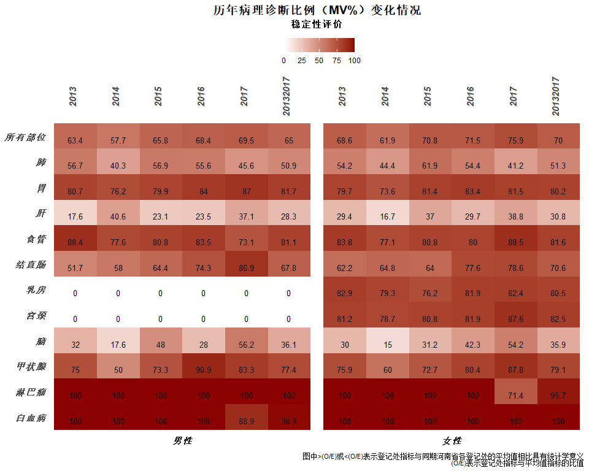

### 7.2.2 与区域标准比较

本部分主要通过把MV与河南省所有上报五大洲数据的平均指标相比来表示差异大小,指标为(O/E)。

> $$(O/E)=\frac{登记处MV}{同时期内所有上报五大洲登记处平均期望值}$$

> 采用五大洲发病率第10卷统计学方法进行差异的统计学检验，“>”/“<”表示与期望值相比差异具有统计学意义。

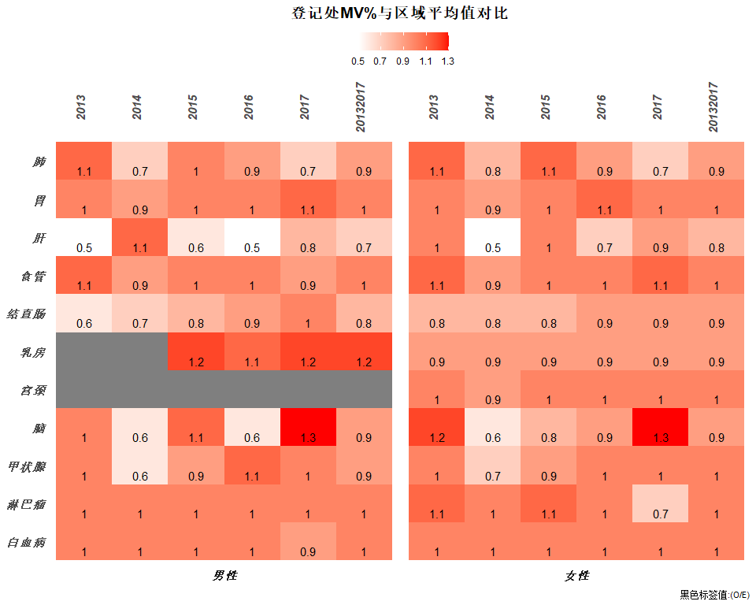

### 7.2.3 与国家平均水平比较

> 本部分指标通过登记处期间（2013-2017）MV%指标值与全国（城市和农村）平均指标值进行对比来展示该指标的合理性。

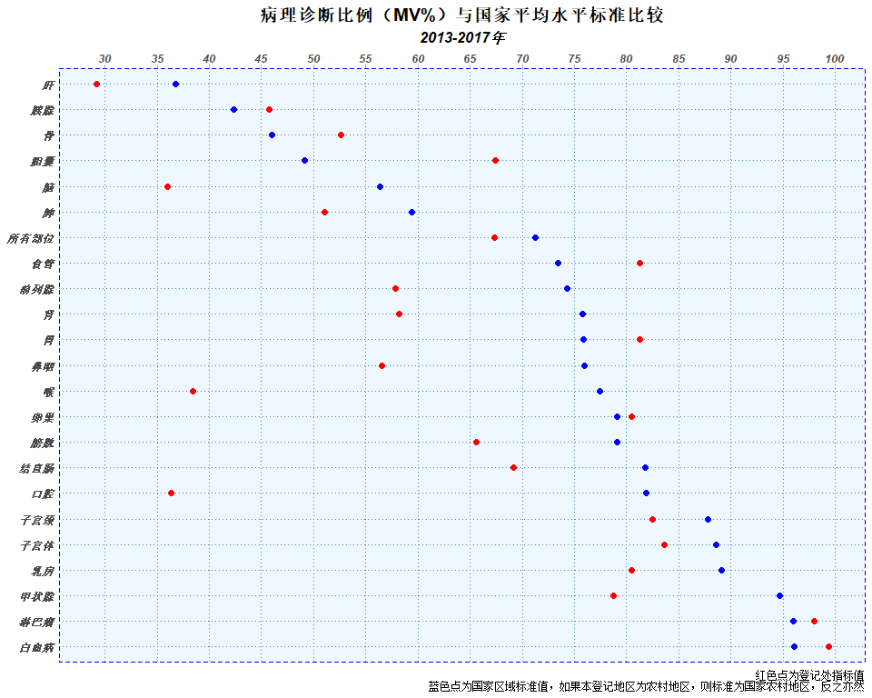

## 7.3 死亡发病比（M:I）

> $$M:I=\frac{时期内癌症死亡数}{时期内新发病例数}$$
> 1. M:I相对过大，提示*发病登记可能存在漏报*，同时还要考虑生命统计的数据完整性和有效性问题；
> 2. M:I相对过小，提示发病数据中有*重复记录*可能或*死亡漏报*；
> 3. M:I值大小与生存率以及 死亡证书质量（根本死因的准确性）相关；
> 4. M:I值应该与相似地区M:I值相近，不同年份之间M:I值不会有大的波动。

### 7.3.1 稳定性评价

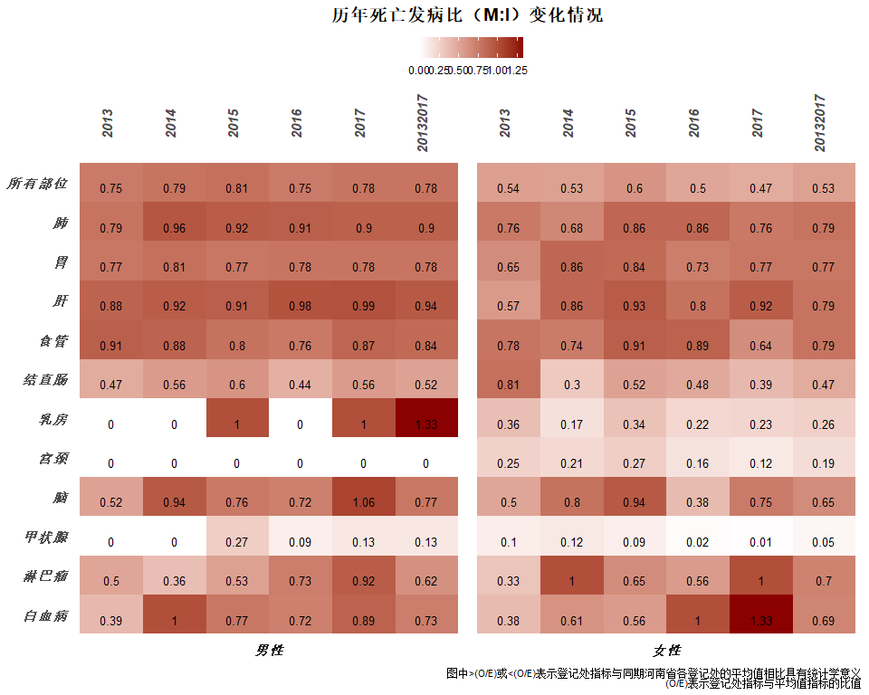

### 7.3.2 与区域标准比较

本部分主要通过把M:I与河南省所有上报五大洲数据的平均指标相比来表示差异大小,指标为(O/E)。

> $$(O/E)=\frac{登记处M:I}{同时期内所有上报五大洲登记处平均期望值}$$

> 采用五大洲发病率第10卷统计学方法进行差异的统计学检验，“>”/“<”表示与期望值相比差异具有统计学意义。

[figure not shown]

### 7.3.3 与国家平均水平比较

> 本部分指标通过登记处期间（2013-2017）M:I指标值与全国（城市和农村）平均指标值进行对比来展示该指标的合理性。

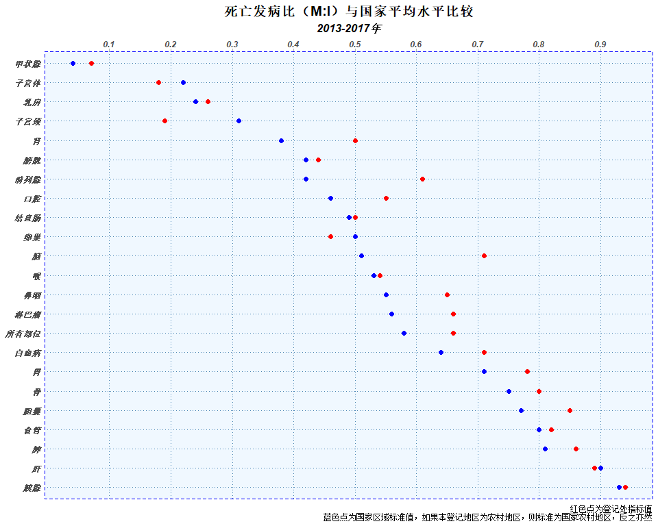

## 7.4 只有死亡医学证明书比例(DCO%)

### 7.4.1 稳定性评价

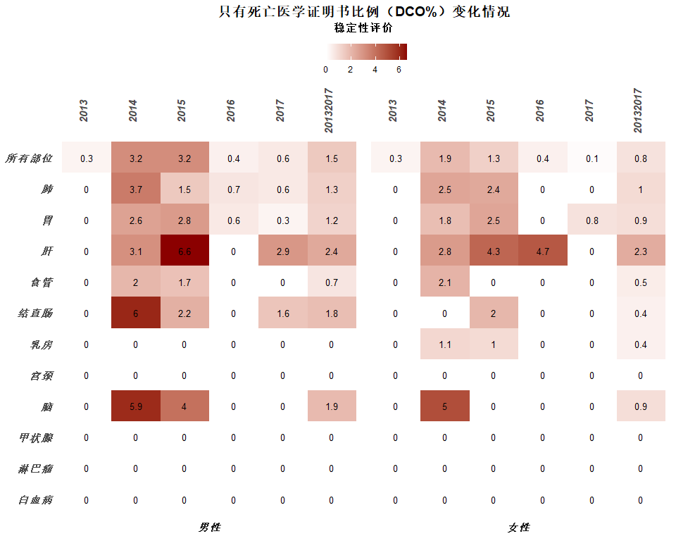

### 7.4.2 与国家平均水平比较

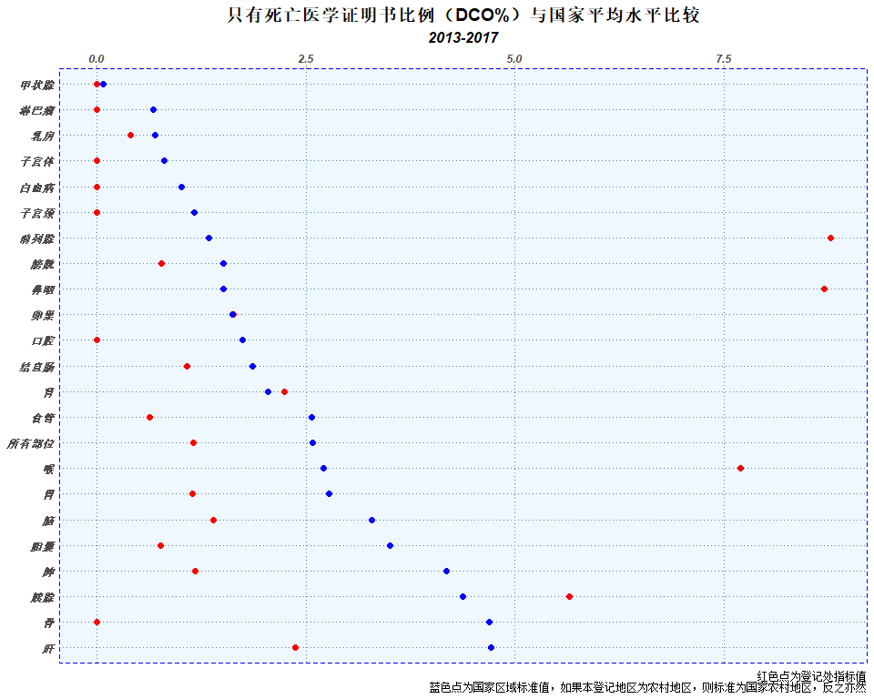

[^1]: https://blog.csdn.net/weixin_40628687/article/details/81751203